# Headings and Subtotals

A common task in the market-research world is to take data that is essentially a scale collapse it into a smaller number of bins. For example, if you asked people to rate their preference on a scale of 1-10 you might want to see how the people who provide a rating between 1 and 5 compare to those who rated it between 6 and 10. This goes by a number of names like *Top Box*, *Top Two Box*, or *Nets*, but in Crunch we it is called a *Subtotal*.

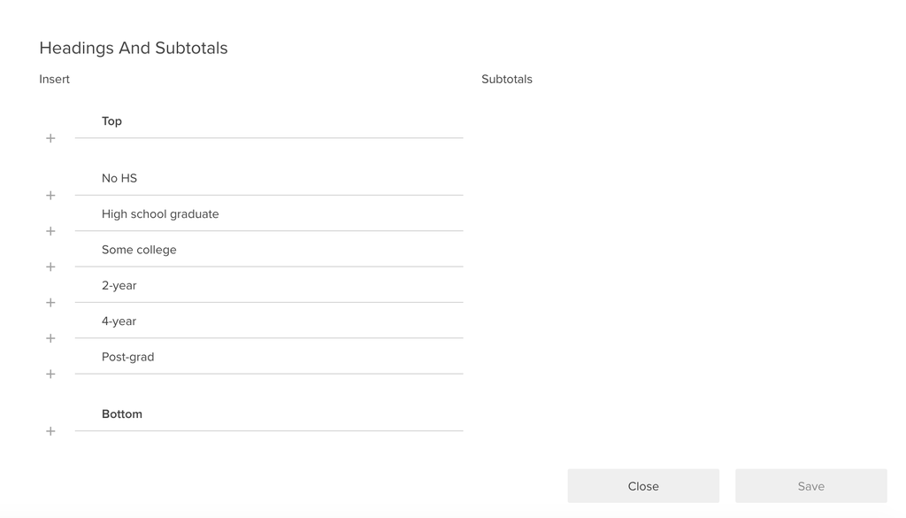

.

To create either headings or subtotals, first click the plus sign where you want the heading to appear in the list of categorical variables.

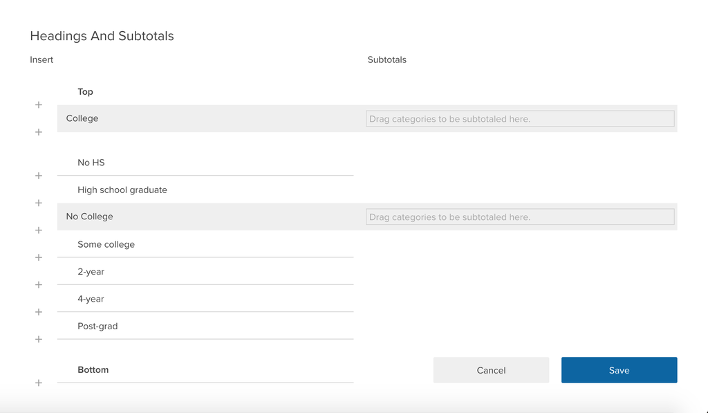

If you stop here you will have created a *Heading* which is just a label that helps organize the categories in a categorical variable. If you want to turn these headings into subtotals, drag the variable which you want to sum into the heading.

[figure not shown]

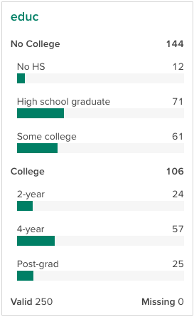

Whenever you include this variable in an analysis or multitable, the subtotals will be cross-tabulated just like any other category. For example here we want to see the our subtotals by gender:

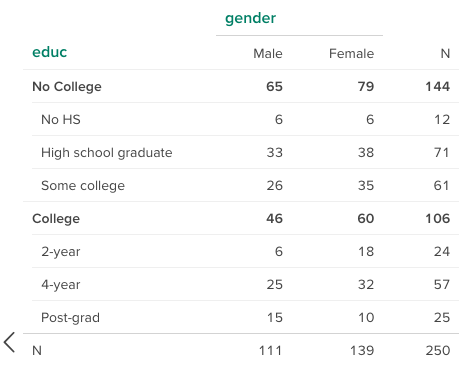